# Lab 3

### Calculating Values RSS, MSS, and TSS, and interpreting values

```r
#residual sum of squares
RSS=with(spruce.df,sum((Height-yhat)^2))
RSS
```

```
## [1] 95.70281
```

```r
#model sum of squares
MSS=with(spruce.df,sum((yhat-mean(Height))^2))
MSS
```

```
## [1] 183.2447
```

```r
#total sum of squares
TSS=with(spruce.df,sum((Height-mean(Height))^2))
TSS
```

```
## [1] 278.9475
```

Here are some other required calculations:

```r
MSS/TSS
```

```
## [1] 0.6569146
```

This number of MSS/TSS represents how well the model fits the data, as the calculation for MSS/TSS is equal to R^2 (MSS/TSS=R^2), our correlation coefficient. In the case of this data, we can say there is a moderate correlation between Height and BHDiameter, due to our R^2 value of .6569146.

```r
TSS
```

```
## [1] 278.9475
```

```r
RSS+MSS
```

```
## [1] 278.9475
```

As you can see, the sum of RSS and MSS are equal to TSS.

## Task 5

### Summary/Equation of Best Fit Line

Here is the summary for spruce.lm

```r
summary(spruce.lm)
```

```
##
## Call:
## lm(formula = Height ~ BHDiameter)
##
## Residuals:
##     Min      1Q  Median      3Q     Max
## -3.9394 -0.9763  0.2829  0.9950  2.6644
##
## Coefficients:
##             Estimate Std. Error t value Pr(>|t|)
## (Intercept)  9.14684    1.12131   8.157 1.63e-09 ***
## BHDiameter   0.48147    0.05967   8.069 2.09e-09 ***
## ---
## Signif. codes:  0 '***' 0.001 '**' 0.01 '*' 0.05 '.' 0.1 ' ' 1
##
## Residual standard error: 1.678 on 34 degrees of freedom
## Multiple R-squared:  0.6569, Adjusted R-squared:  0.6468
## F-statistic:  65.1 on 1 and 34 DF,  p-value: 2.089e-09
```

```r
coef(spruce.lm)
```

```
## (Intercept)  BHDiameter
##   9.1468390   0.4814743
```

```r
#Slope coefficient: .48147
#Intercept coefficient: 9.14684
#Equation: Height = 9.14684 + .48147*BHDiameter
```

The coefficients can be found in the ‘Estimates’ column, or under the results produced by the coef() method. The estimated slope is 0.48147, while the estimated intercept is 9.14684  
Therefore, the equation of the fitted line made by spruce.lm is: Height = 9.146839 + .4814743 * BHDiameter

### Prediction of Height of Spruce at Preset Diameters

```r
#predict height at 15, 18, 20 cm
predict(spruce.lm, data.frame(BHDiameter=c(15,18,20)))
```

```
##        1        2        3
## 16.36895 17.81338 18.77632
```

So then, we can see that for the tree with a 15 cm diameter, the predicted height is 16.37, for the tree with the 18 cm diameter, the predicted height is 17.81, and for the tree with the 20 cm diameter, the predicted height is 18.78

## Task 6

Making a gg plot of the data:

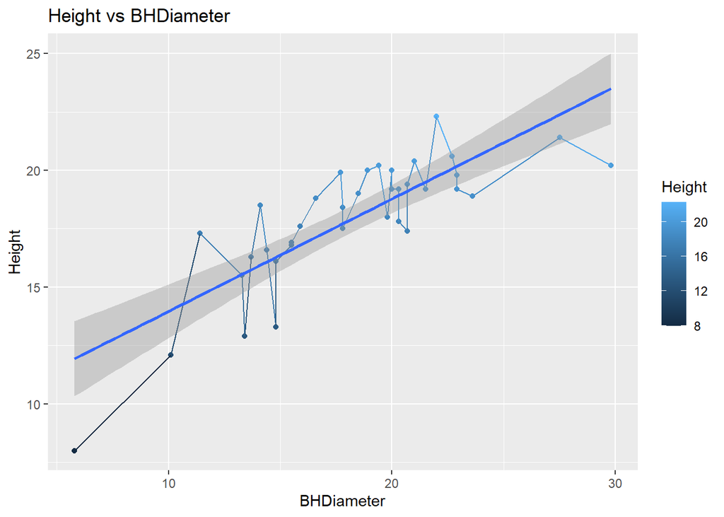

```r
library(ggplot2)
g=ggplot(spruce.df, aes(x=BHDiameter,y=Height, color=Height))
g=g+geom_point() + geom_line()+ geom_smooth(method="lm")
g+ggtitle("Height vs BHDiameter")
```

## Task 7

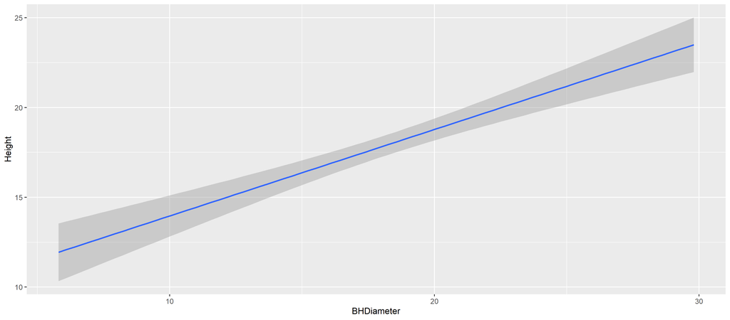

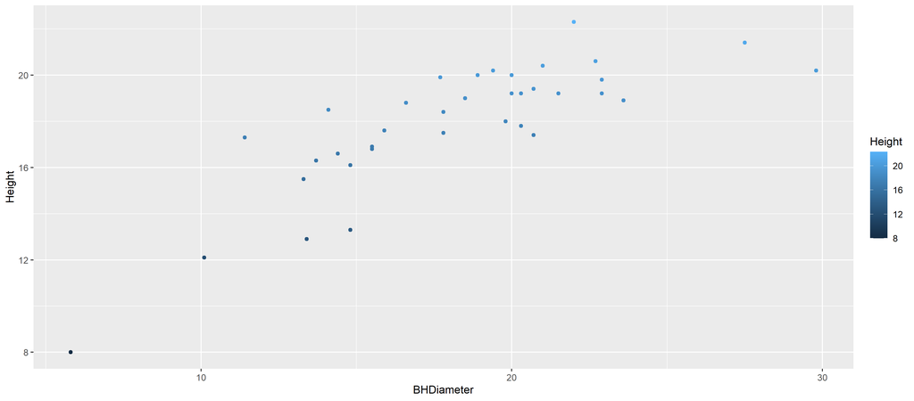

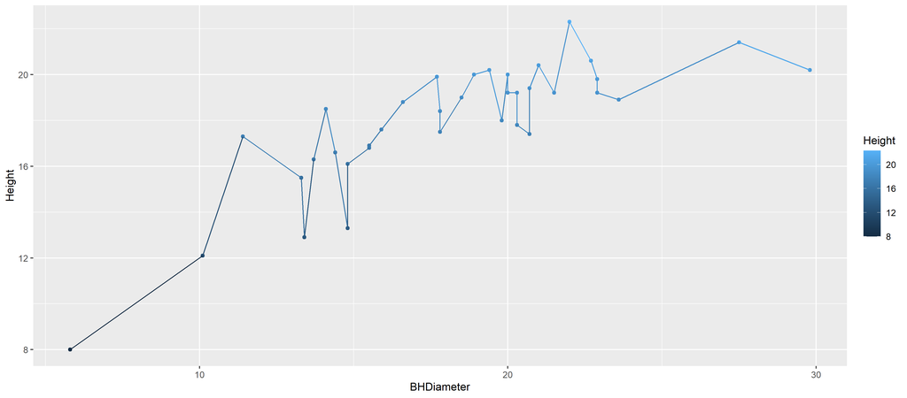